# Balance Assessment and Survival Analysis | Tz/Dz/Az vs Tamsulosin

Jacob Simmering, PhD https://jacobsimmering.com (University of Iowa)https://uiowa.edu  
2023-11-09

```r
library("Rcpp")
library(tidyverse)
library(gtsummary)
library(survival)
library(effectsize)
library(patchwork)
```

This file was compiled on 2023-11-09 13:07:01 by `jsimmeri` on MNF091.

The script `analysis_functions.R` provides:

1. some functions for summarizing the cohort and building tables that are shared across scripts
2. code to load the entire collection out outcomes data (which it returns as `model_data` to the workspace)
3. sets `root_dir` according to the location where the script is being run to handle different syntax for referring to network drives in MacOS and CentOS

```r
source("~/projects/dlb-tz/analysis/analysis_functions.R")
```

## Data Load

### Unadjusted Data

The tibble `model_data` is loaded by `analysis_functions` `model_data` contains data on all users of the three drugs. We want to reduce that here to just Tz/Dz/Az and tamsulosin.

```r
model_data <- model_data %>%
  filter(two_rx == TRUE) %>%
  filter(drug %in% c("tamsulosin", "tz/dz/az")) %>%
  mutate(treatment = drug == "tz/dz/az")
```

### Matches

We also want to load our matching results:

```r
matches <- read_rds(glue::glue("/{shared_dir}/lss_jsimmeri/LBD/matches_tz_tam_2rx.rds"))
```

```r
matched_model_data <- model_data %>%
  select(-treatment) %>%
  inner_join(matches,
    by = "enrolid")
```

## Balance and Cohort Description

### Before Matching

```r
describe_cohort(model_data)
```

| Group | Characteristic | tamsulosin, N = 437,045 | tz/dz/az, N = 126,313 | Difference |
| --- | --- | --- | --- | --- |
| Age and Medication Start Time | Age at Index Date | 62 (56, 71) | 62 (55, 70) | 0.06 |
|  | Medication Index Date | 2,012.0 (2,008.0, 2,014.0) | 2,009.0 (2,006.0, 2,012.0) | 0.48 |
| Duration of Enrollment Time | Lookback Time (Years) | 3.6 (2.0, 6.3) | 2.9 (1.7, 5.2) | 0.24 |
|  | Follow Up Time (Years) | 1.90 (0.86, 3.78) | 1.96 (0.93, 4.19) | -0.08 |
| Rates of Inpatient and Outpatient Encounters | Inpatient Events Per Year | 0.00 (0.00, 0.22) | 0.00 (0.00, 0.13) | 0.08 |
|  | Outpatient Events Per Year | 10 (5, 18) | 9 (5, 16) | 0.07 |
|  | Mean Number of DX Codes Per Outpatient Event | 1.56 (1.27, 2.09) | 1.36 (1.18, 1.83) | 0.28 |
|  | Outpatient DX Code Incidence Per Year | 0.04 (0.02, 0.08) | 0.04 (0.02, 0.07) | 0.13 |
|  | mean_ndx_out_rate | 16 (9, 29) | 14 (7, 25) | 0.13 |
| Elixhauser/AHRQ Comorbidity Flags | Alcohol Abuse | 11,379 (2.6%) | 2,680 (2.1%) | 0.01 |
|  | Anemia | 68,691 (15.7%) | 17,016 (13.5%) | 0.03 |
|  | Blood Loss | 7,232 (1.7%) | 1,514 (1.2%) | 0.02 |
|  | Heart Failure | 42,970 (9.8%) | 10,207 (8.1%) | 0.02 |
|  | Coagulopathy | 18,949 (4.3%) | 3,645 (2.9%) | 0.03 |
|  | Depression | 43,797 (10.0%) | 8,991 (7.1%) | 0.04 |
|  | Diabetes Without Complications | 121,292 (27.8%) | 36,574 (29.0%) | 0.01 |
|  | Diabetes With Complications | 46,695 (10.7%) | 14,387 (11.4%) | 0.01 |
|  | Drug Abuse | 6,690 (1.5%) | 1,331 (1.1%) | 0.02 |
|  | Fluid or Electrolyte Disorders | 56,021 (12.8%) | 13,805 (10.9%) | 0.02 |
|  | HIV | 1,438 (0.3%) | 486 (0.4%) | 0.00 |
|  | HTN Without Complications | 271,591 (62.1%) | 87,650 (69.4%) | 0.06 |
|  | HTN With Complications | 57,049 (13.1%) | 20,761 (16.4%) | 0.04 |
|  | Hypothyroidism | 43,432 (9.9%) | 9,809 (7.8%) | 0.03 |
|  | Liver Disease | 24,205 (5.5%) | 4,845 (3.8%) | 0.03 |
|  | Lymphoma | 6,367 (1.5%) | 1,322 (1.0%) | 0.01 |
|  | Metastatic Cancer | 10,716 (2.5%) | 1,555 (1.2%) | 0.03 |
|  | Other Neurologic Disorders | 45,438 (10.4%) | 8,237 (6.5%) | 0.06 |
|  | Obesity | 48,019 (11.0%) | 11,470 (9.1%) | 0.03 |
|  | Paralysis | 10,583 (2.4%) | 2,087 (1.7%) | 0.02 |
|  | Pulmonary Hypertension | 13,310 (3.0%) | 2,458 (1.9%) | 0.03 |
|  | Psychoses | 32,490 (7.4%) | 6,910 (5.5%) | 0.03 |
|  | Peptic Ulcer Disease | 1,709 (0.4%) | 297 (0.2%) | 0.01 |
|  | COPD | 104,627 (23.9%) | 24,107 (19.1%) | 0.05 |
|  | Peripheral Vascular Disease | 65,114 (14.9%) | 15,324 (12.1%) | 0.03 |
|  | Renal Failure | 31,280 (7.2%) | 12,096 (9.6%) | 0.04 |
|  | Rheumatoid Arthritis | 22,205 (5.1%) | 4,754 (3.8%) | 0.03 |
|  | Solid Tumor | 73,745 (16.9%) | 13,905 (11.0%) | 0.07 |
|  | Valvular Disease | 62,332 (14.3%) | 14,081 (11.1%) | 0.04 |
|  | Weight Loss | 20,140 (4.6%) | 3,448 (2.7%) | 0.04 |
| Hypotension | Orthostatic Hypotension | 5,423 (1.2%) | 944 (0.7%) | 0.02 |
|  | Other Hypotension | 13,208 (3.0%) | 2,202 (1.7%) | 0.03 |
| Prostate Specific Antigen | PSA Measurement Taken | 249,926 (57.2%) | 72,215 (57.2%) | 0.00 |
|  | Diagnosis of Abnormal PSA | 70,538 (16.1%) | 14,099 (11.2%) | 0.06 |
| Bladder Function and Urinary Flow | Slow Urinary Stream Diagnosis | 13,752 (3.1%) | 2,948 (2.3%) | 0.02 |
|  | Uroflow Study Performed | 28,542 (6.5%) | 7,684 (6.1%) | 0.01 |
|  | Cystometrogram Performed | 3,485 (0.8%) | 937 (0.7%) | 0.00 |
|  | Diagnosis of BPH | 183,019 (41.9%) | 42,481 (33.6%) | 0.07 |
| Other Comorbidities | Diagnosis of Anxiety | 39,365 (9.0%) | 7,827 (6.2%) | 0.04 |
|  | Diagnosis of Erectile Dysfunction | 45,596 (10.4%) | 11,268 (8.9%) | 0.02 |

### After Matching

```r
describe_cohort(matched_model_data)
```

| Group | Characteristic | tamsulosin, N = 121,358 | tz/dz/az, N = 121,358 | Difference |
| --- | --- | --- | --- | --- |
| Age and Medication Start Time | Age at Index Date | 62 (55, 70) | 62 (55, 70) | 0.01 |
|  | Medication Index Date | 2,009.0 (2,006.0, 2,012.0) | 2,009.0 (2,006.0, 2,012.0) | 0.01 |
| Duration of Enrollment Time | Lookback Time (Years) | 3.21 (1.89, 5.49) | 2.94 (1.76, 5.30) | 0.06 |
|  | Follow Up Time (Years) | 2.06 (0.92, 4.28) | 2.05 (0.93, 4.28) | 0.00 |
| Rates of Inpatient and Outpatient Encounters | Inpatient Events Per Year | 0.00 (0.00, 0.14) | 0.00 (0.00, 0.14) | 0.01 |
|  | Outpatient Events Per Year | 9 (5, 17) | 9 (5, 16) | 0.01 |
|  | Mean Number of DX Codes Per Outpatient Event | 1.38 (1.19, 1.87) | 1.38 (1.19, 1.85) | 0.01 |
|  | Outpatient DX Code Incidence Per Year | 0.04 (0.02, 0.07) | 0.04 (0.02, 0.07) | 0.01 |
|  | mean_ndx_out_rate | 14 (7, 25) | 14 (7, 25) | 0.01 |
| Elixhauser/AHRQ Comorbidity Flags | Alcohol Abuse | 2,670 (2.2%) | 2,628 (2.2%) | 0.00 |
|  | Anemia | 16,774 (13.8%) | 16,530 (13.6%) | 0.00 |
|  | Blood Loss | 1,512 (1.2%) | 1,492 (1.2%) | 0.00 |
|  | Heart Failure | 10,289 (8.5%) | 9,931 (8.2%) | 0.01 |
|  | Coagulopathy | 3,621 (3.0%) | 3,580 (2.9%) | 0.00 |
|  | Depression | 8,973 (7.4%) | 8,887 (7.3%) | 0.00 |
|  | Diabetes Without Complications | 35,321 (29.1%) | 35,178 (29.0%) | 0.00 |
|  | Diabetes With Complications | 13,721 (11.3%) | 13,825 (11.4%) | 0.00 |
|  | Drug Abuse | 1,322 (1.1%) | 1,315 (1.1%) | 0.00 |
|  | Fluid or Electrolyte Disorders | 13,649 (11.2%) | 13,421 (11.1%) | 0.00 |
|  | HIV | 489 (0.4%) | 472 (0.4%) | 0.00 |
|  | HTN Without Complications | 84,253 (69.4%) | 83,676 (68.9%) | 0.01 |
|  | HTN With Complications | 20,108 (16.6%) | 19,729 (16.3%) | 0.00 |
|  | Hypothyroidism | 9,665 (8.0%) | 9,610 (7.9%) | 0.00 |
|  | Liver Disease | 4,780 (3.9%) | 4,790 (3.9%) | 0.00 |
|  | Lymphoma | 1,279 (1.1%) | 1,301 (1.1%) | 0.00 |
|  | Metastatic Cancer | 1,620 (1.3%) | 1,547 (1.3%) | 0.00 |
|  | Other Neurologic Disorders | 8,407 (6.9%) | 8,157 (6.7%) | 0.00 |
|  | Obesity | 11,448 (9.4%) | 11,313 (9.3%) | 0.00 |
|  | Paralysis | 2,163 (1.8%) | 2,061 (1.7%) | 0.00 |
|  | Pulmonary Hypertension | 2,590 (2.1%) | 2,433 (2.0%) | 0.00 |
|  | Psychoses | 6,974 (5.7%) | 6,844 (5.6%) | 0.00 |
|  | Peptic Ulcer Disease | 311 (0.3%) | 295 (0.2%) | 0.00 |
|  | COPD | 23,993 (19.8%) | 23,664 (19.5%) | 0.00 |
|  | Peripheral Vascular Disease | 15,208 (12.5%) | 14,977 (12.3%) | 0.00 |
|  | Renal Failure | 11,642 (9.6%) | 11,460 (9.4%) | 0.00 |
|  | Rheumatoid Arthritis | 4,605 (3.8%) | 4,667 (3.8%) | 0.00 |
|  | Solid Tumor | 13,861 (11.4%) | 13,720 (11.3%) | 0.00 |
|  | Valvular Disease | 14,157 (11.7%) | 13,866 (11.4%) | 0.00 |
|  | Weight Loss | 3,521 (2.9%) | 3,416 (2.8%) | 0.00 |
| Hypotension | Orthostatic Hypotension | 991 (0.8%) | 939 (0.8%) | 0.00 |
|  | Other Hypotension | 2,209 (1.8%) | 2,175 (1.8%) | 0.00 |
| Prostate Specific Antigen | PSA Measurement Taken | 69,873 (57.6%) | 69,205 (57.0%) | 0.01 |
|  | Diagnosis of Abnormal PSA | 14,114 (11.6%) | 13,890 (11.4%) | 0.00 |
| Bladder Function and Urinary Flow | Slow Urinary Stream Diagnosis | 3,059 (2.5%) | 2,931 (2.4%) | 0.00 |
|  | Uroflow Study Performed | 7,859 (6.5%) | 7,567 (6.2%) | 0.00 |
|  | Cystometrogram Performed | 992 (0.8%) | 926 (0.8%) | 0.00 |
|  | Diagnosis of BPH | 42,736 (35.2%) | 41,698 (34.4%) | 0.01 |
| Other Comorbidities | Diagnosis of Anxiety | 7,759 (6.4%) | 7,749 (6.4%) | 0.00 |
|  | Diagnosis of Erectile Dysfunction | 11,226 (9.3%) | 11,079 (9.1%) | 0.00 |

## Propensity Score Overlap

We can also visually inspect the estimated propensity scores for overlap:

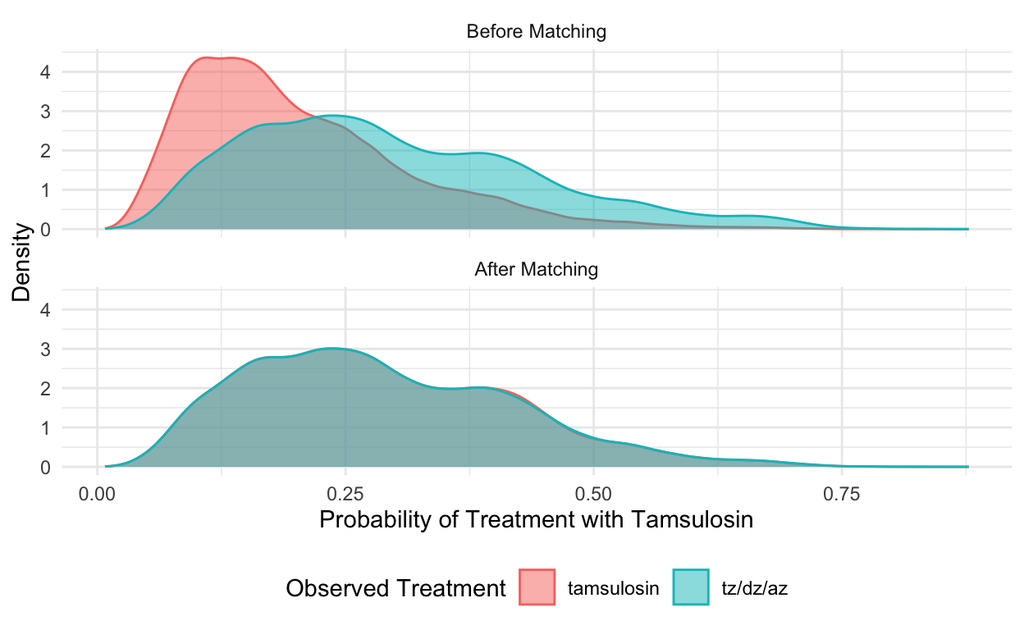

```r
ps <- read_rds(glue::glue("/{shared_dir}/lss_jsimmeri/LBD/model_tz_tam_2rx.rds"))
bind_rows(
  model_data %>%
    inner_join(ps, by = "enrolid") %>%
    mutate(type = "Before Matching"),
  matched_model_data %>%
    inner_join(ps, by = "enrolid") %>%
    mutate(type = "After Matching")
  ) %>%
  mutate(type = forcats::fct_rev(type)) %>%
  ggplot(aes(x = ptx, fill = drug, color = drug)) +
  geom_density(alpha = 0.5) +
  labs(x = "Probability of Treatment with Tamsulosin",
       y = "Density",
       color = "Observed Treatment",
       fill = "Observed Treatment") +
  theme_minimal() +
  theme(legend.position = "bottom") +
  facet_wrap(~ type, nrow = 2)
```

## Survival Analysis

### Before Matching

```r
km_unadjust <-survfit(Surv(survival_time, develops_pd) ~ treatment,
        data = model_data) %>%
  broom::tidy() %>%
  mutate(treatment = ifelse(strata == "treatment=TRUE",
    "tz/dz/az", "Tamsulosin")) %>%
  ggplot(
    aes(
      x = time / 365,
      y = 100 * estimate,
      ymin = 100 * conf.low,
      ymax = 100 * conf.high
    )
  ) +
  geom_step(aes(color = treatment)) +
  geom_ribbon(aes(fill = treatment), alpha = 0.25) +
  theme_minimal() +
  labs(x = "Years of Follow Up", y = "Percent Remaining LBD Free",
       color = "", fill = "") +
  theme(legend.position = c(0.25, 0.25))
```

A finding that is statistically significant using the log rank test:

```r
survdiff(Surv(survival_time, develops_pd) ~ treatment,
         data = model_data)
```

```
Call:
survdiff(formula = Surv(survival_time, develops_pd) ~ treatment,
    data = model_data)

                     N Observed Expected (O-E)^2/E (O-E)^2/V
treatment=FALSE 437045     1286     1125      23.2      96.4
treatment=TRUE  126313      195      356      73.1      96.4

 Chisq= 96.4  on 1 degrees of freedom, p= <2e-16
```

```r
raw_cox <- coxph(Surv(survival_time, develops_pd) ~ as.numeric(treatment),
                 data = model_data,
                 robust = TRUE)
tbl_regression(raw_cox, exponentiate = TRUE)
```

| **Characteristic** | **HR**<sup>1</sup> | **95% CI**<sup>1</sup> | **p-value** |
| --- | --- | --- | --- |
| as.numeric(treatment) | 0.48 | 0.41, 0.56 | <0.001 |

<sup>1</sup> HR = Hazard Ratio, CI = Confidence Interval

However, this estimate is not trustworthy as we know the groups could be better balanced.

### With Propensity Score Matching

Further adjustment yields similar results.

We observe the following overall incidence:

```r
matched_model_data %>%
  group_by(drug) %>%
  summarize(
    cases = sum(develops_pd),
    time = sum(survival_time / 365),
    incidence = cases / time * 10000
  ) %>%
  knitr::kable()
```

| drug | cases | time | incidence |
| --- | --- | --- | --- |
| tamsulosin | 323 | 364944.9 | 8.850651 |
| tz/dz/az | 193 | 365311.1 | 5.283169 |

```r
km_adjust <-survfit(Surv(survival_time, develops_pd) ~ drug,
        data = matched_model_data) %>%
  broom::tidy() %>%
  mutate(treatment = ifelse(strata == "drug=tz/dz/az",
    "tz/dz/az", "Tamsulosin")) %>%
  ggplot(
    aes(
      x = time / 365,
      y = 100 * estimate,
      ymin = 100 * conf.low,
      ymax = 100 * conf.high
    )
  ) +
  geom_step(aes(color = treatment)) +
  geom_ribbon(aes(fill = treatment), alpha = 0.25) +
  theme_minimal() +
  labs(x = "Years of Follow Up", y = "Percent Remaining LBD Free",
       color = "", fill = "") +
  theme(legend.position = c(0.25, 0.25))
```

The population size at risk by year is given in the table below:

```r
survfit(Surv(survival_time, develops_pd) ~ drug,
        data = matched_model_data) %>%
  broom::tidy() %>%
  select(strata, time,, n.risk) %>%
  complete(strata, time = 0:(16*365)) %>%
  fill(n.risk, .direction = "down") %>%
  mutate(drug = ifelse(strata == "drug=tamsulosin", "Tamsulosin", "TZ/DZ/AZ")) %>%
  select(time, drug, n.risk) %>%
  filter(time %in% c(1:16 * 365)) %>%
  mutate(year = round(time / 365)) %>%
  spread(drug, n.risk) %>%
  knitr::kable()
```

| time | year | Tamsulosin | TZ/DZ/AZ |
| --- | --- | --- | --- |
| 365 | 1 | 88233 | 88226 |
| 730 | 2 | 61826 | 61459 |
| 1095 | 3 | 45137 | 44995 |
| 1460 | 4 | 33133 | 33055 |
| 1825 | 5 | 23982 | 23956 |
| 2190 | 6 | 17304 | 17281 |
| 2555 | 7 | 12520 | 12444 |
| 2920 | 8 | 8491 | 8503 |
| 3285 | 9 | 5642 | 5651 |
| 3650 | 10 | 3584 | 3638 |
| 4015 | 11 | 2199 | 2186 |
| 4380 | 12 | 1167 | 1142 |
| 4745 | 13 | 659 | 653 |
| 5110 | 14 | 314 | 320 |
| 5475 | 15 | 123 | 118 |
| 5840 | 16 | 3 | 3 |

A log rank test confirms that the curves remain different.

```r
survdiff(Surv(survival_time, develops_pd) ~ treatment,
         data = matched_model_data)
```

```
Call:
survdiff(formula = Surv(survival_time, develops_pd) ~ treatment,
    data = matched_model_data)

                 N Observed Expected (O-E)^2/E (O-E)^2/V
treatment=0 121358      323      258      16.5      32.9
treatment=1 121358      193      258      16.4      32.9

 Chisq= 32.9  on 1 degrees of freedom, p= 1e-08
```

Survival times

```r
tbl_survfit(
  survfit(
    Surv(survival_time, develops_pd) ~ drug, data = matched_model_data
  ),
  probs = seq(0.5, 2, by = 0.5) / 100
)
```

| **Characteristic** | **0.5% Percentile** | **1.0% Percentile** | **1.5% Percentile** | **2.0% Percentile** |
| --- | --- | --- | --- | --- |
| drug |  |  |  |  |
| tamsulosin | 2,212 (1,991, 2,489) | 3,235 (2,953, 3,566) | 4,640 (3,711, —) | 4,834 (4,675, —) |
| tz/dz/az | 2,855 (2,554, 3,158) | 4,773 (4,386, —) | — (4,773, —) | — (—, —) |

We fit a Cox regression model to estimate the differences in hazard:

```r
full_cox <- coxph(Surv(survival_time, develops_pd) ~ as.numeric(treatment),
                       data = matched_model_data,
                       robust = TRUE)
tbl_regression(full_cox, exponentiate = TRUE)
```

| **Characteristic** | **HR**<sup>1</sup> | **95% CI**<sup>1</sup> | **p-value** |
| --- | --- | --- | --- |
| as.numeric(treatment) | 0.60 | 0.50, 0.71 | <0.001 |

<sup>1</sup> HR = Hazard Ratio, CI = Confidence Interval

## Fit Summaries

```r
tbl_merge(
  tbls = list(
    tbl_regression(raw_cox, exponentiate = TRUE),
    tbl_regression(full_cox, exponentiate = TRUE)
  ),
  tab_spanner = c("Unadjusted", "Propensity Score Matched")
) %>%
  as_flex_table()
```

| Characteristic | Unadjusted HR1 | Unadjusted 95% CI1 | Unadjusted p-value | Propensity Score Matched HR1 | Propensity Score Matched 95% CI1 | Propensity Score Matched p-value |
| --- | --- | --- | --- | --- | --- | --- |
| as.numeric(treatment) | 0.48 | 0.41, 0.56 | <0.001 | 0.60 | 0.50, 0.71 | <0.001 |

1HR = Hazard Ratio, CI = Confidence Interval

## Diagnostics

```r
scf_residuals <- cox.zph(full_cox)
scf_residuals
```

```
                       chisq df   p
as.numeric(treatment) 0.0623  1 0.8
GLOBAL                0.0623  1 0.8
```

```r
with(scf_residuals, cor.test(x, y))
```

```
    Pearson's product-moment correlation

data:  x and y
t = -0.24928, df = 514, p-value = 0.8032
alternative hypothesis: true correlation is not equal to 0
95 percent confidence interval:
 -0.09722163  0.07539600
sample estimates:
        cor
-0.01099472
```

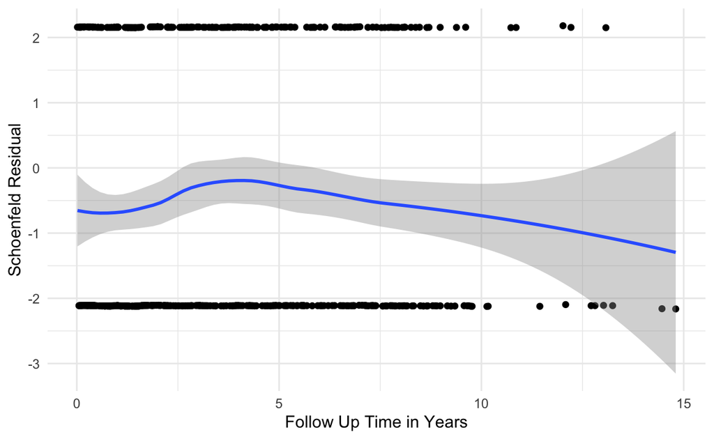

```r
tibble(
  x = scf_residuals$time,
  y = scf_residuals$y
) %>%
  ggplot(aes(x = x / 365, y = y)) +
  geom_point() +
  geom_smooth(method = "loess") +
  labs(x = "Follow Up Time in Years", y = "Schoenfeld Residual") +
  theme_minimal()
```